# BPA and alternatives similarity score curvep analysis - After Removing Outliers & Using Training Set

#### ANCOVA

| Chemical | Degrees of Freedom | F-Value | P-value | Endpoint |
| --- | --- | --- | --- | --- |
| 1octanol | 5 | 3.422232 | 0.0110470 | pearson |
| 4TPP | 5 | 3.945332 | 0.0051764 | pearson |
| DMSO | 5 | 2.643268 | 0.0367654 | pearson |
| EE2 | 5 | 3.339286 | 0.0125242 | pearson |
| Fadrozole | 5 | 2.901549 | 0.0250826 | pearson |
| Fenitrothion | 5 | 3.395335 | 0.0117106 | pearson |
| Fluoxetine | 5 | 2.670374 | 0.0341851 | pearson |
| Fluoxetine | 2 | 3.896446 | 0.0276704 | pearson |
| Malathion | 5 | 7.900312 | 0.0000257 | pearson |
| Prochloraz | 5 | 4.480032 | 0.0023181 | pearson |
| 1octanol | 5 | 3.624521 | 0.0079922 | spearman |
| 24DNP | 5 | 3.521436 | 0.0098879 | spearman |
| 4TPP | 5 | 5.133384 | 0.0008558 | spearman |
| BPA | 5 | 2.998832 | 0.0210445 | spearman |
| ClofibricAcid | 5 | 3.591934 | 0.0083951 | spearman |
| DES | 5 | 2.944072 | 0.0228885 | spearman |
| Dimethylformamide | 2 | 5.873286 | 0.0059895 | spearman |
| DMSO | 2 | 3.542153 | 0.0378826 | spearman |
| EE2 | 5 | 3.810946 | 0.0064538 | spearman |
| Fadrozole | 5 | 4.384891 | 0.0029072 | spearman |
| Fenitrothion | 5 | 4.496766 | 0.0023318 | spearman |
| Fluoxetine | 5 | 4.078447 | 0.0041558 | spearman |
| Malathion | 5 | 7.167503 | 0.0000592 | spearman |
| Prochloraz | 5 | 7.069331 | 0.0000670 | spearman |
| Trenbolone | 5 | 3.024742 | 0.0194521 | spearman |

#### Dunnett’s Test

| Chemical | Dose | Difference in similarity score (+/- 100) | P-value | Endpoint |
| --- | --- | --- | --- | --- |
| Malathion | Dose4-C | -25.48622 | 0.0198606 | pearson |
| Fenitrothion | Dose2-C | 38.75381 | 0.0050760 | spearman |
| Fenitrothion | Dose4-C | 35.53195 | 0.0073216 | spearman |
| Fenitrothion | Dose5-C | 31.36423 | 0.0221855 | spearman |
| Fluoxetine | Dose1-C | -41.25330 | 0.0066446 | spearman |
| Malathion | Dose4-C | -26.00982 | 0.0082259 | spearman |
| Prochloraz | Dose1-C | -37.15924 | 0.0064657 | spearman |

#### Boxplots by endpoint

##### Pearson

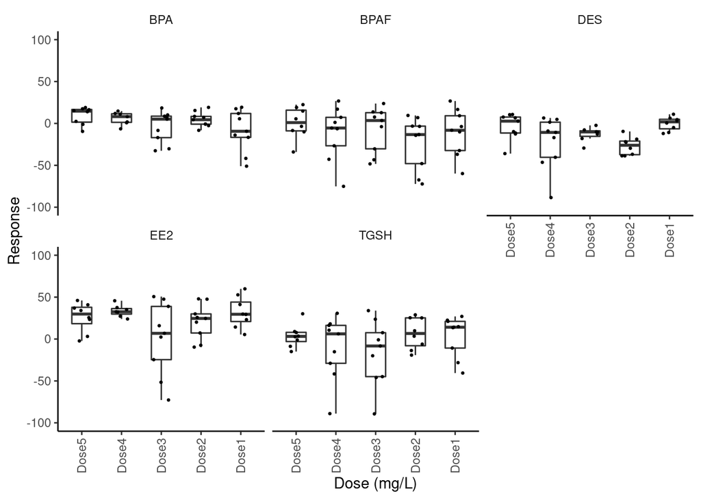

##### Spearman

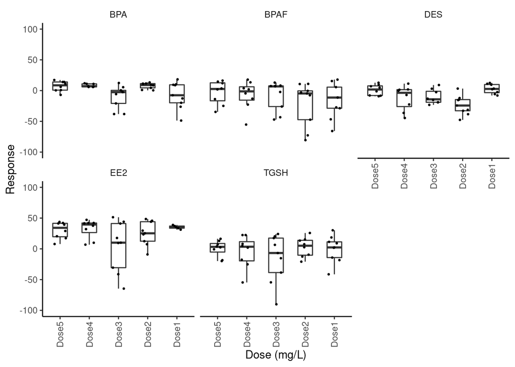

## Similarity Scores/Correlation coefficients

### Benchmark Dose

Since we do not know what the benchmark response is for each one of the chemicals, a method will be used that can estimate a benchmark response (empirically) when given a large enough set of data. The RcurveP package includes an automated process to select an appropriate BMR based off of the data. From Hsieh et al. 2019 manuscript: “The pooled variance of potency of all chemicals per [threshold value (i.e. 5 through 99)] was calculated. The BMR was considered as the [threshold value] at which the potency variance was sufficiently reduced and was the lowest threshold that potency variance was stabilized”.

#### Negative Direction

##### Benchmark Response Plots

###### Pearson

$`1`

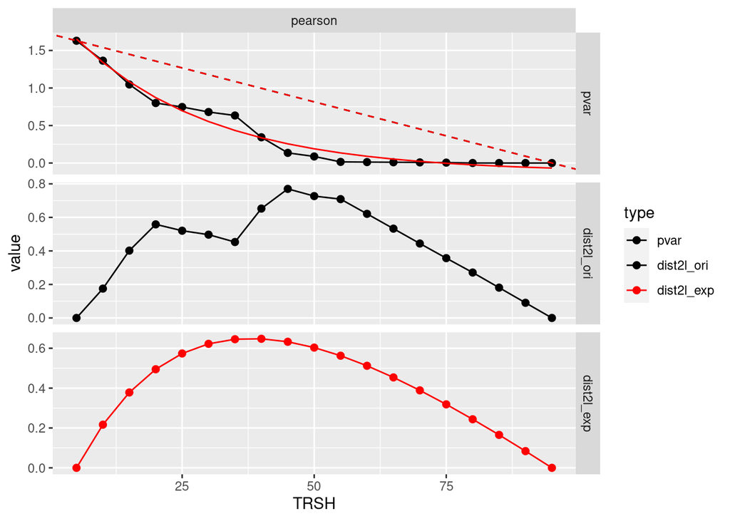

Figure 17. Summary of Benchmark response estimation

###### Spearman

$`1`

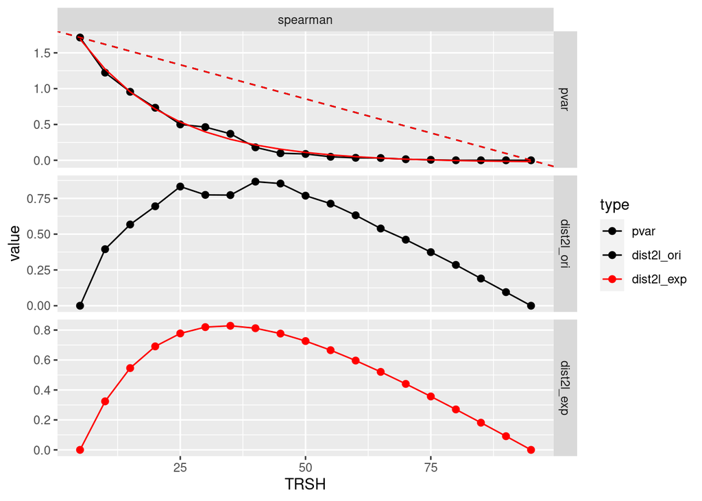

Figure 17. Summary of Benchmark response estimation

Table 8. Summary of the estimated BMR

| Endpoint | Quality Control Message | Correlation of expotential fit | Correlation of linear model fit | BMR of exponential model | BMR of linear model |
| --- | --- | --- | --- | --- | --- |
| pearson | cautionary | 0.9872005 | 0.8897580 | 40 | 45 |
| spearman | cautionary | 0.9975647 | 0.8425282 | 35 | 40 |

From the sampling method, it the benchmark response threshold should be set to 40 for the pearson endpoint and 35 for the spearman endpoint.

BMR - The lowest response threshold at which the variance in potency estimation is sufficiently reduced

###### Pearson simulated curves

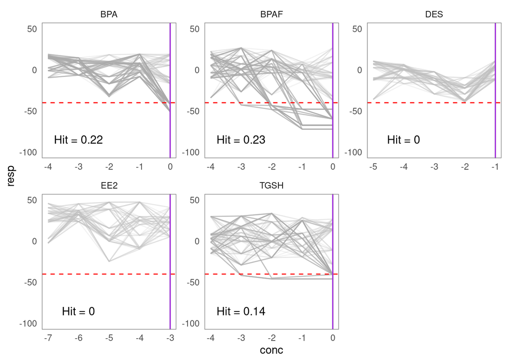

###### Spearman simulated curves

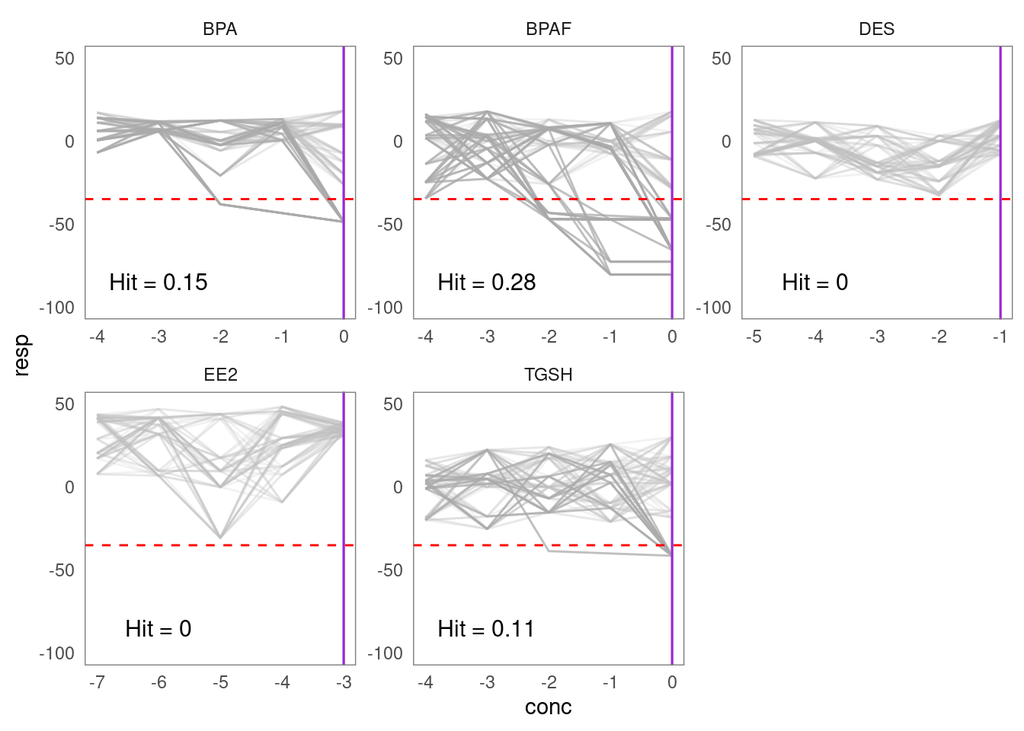

###### Pearson fitted curves (Hill/Constant)

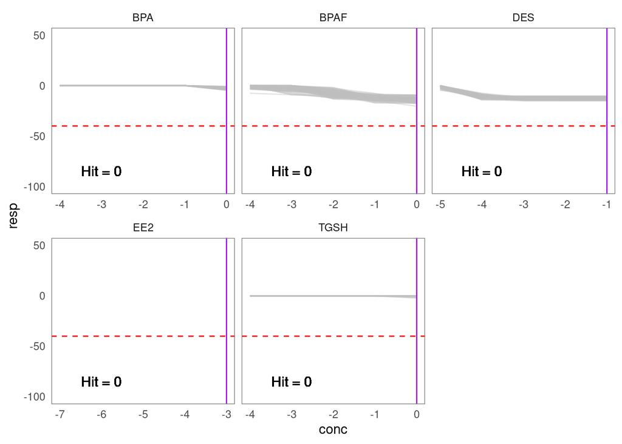

###### Spearman fitted curves (Hill/Constant)

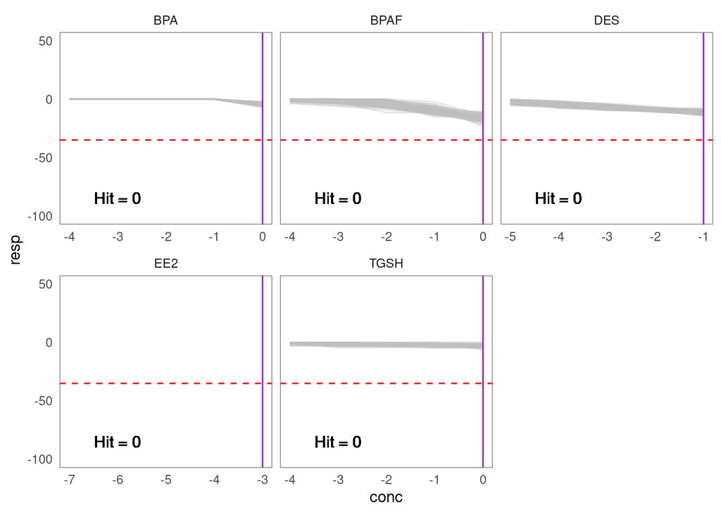

#### Distribution of BMDs

##### Distribution of BMDs from Rcurvep - Pearson c.c.

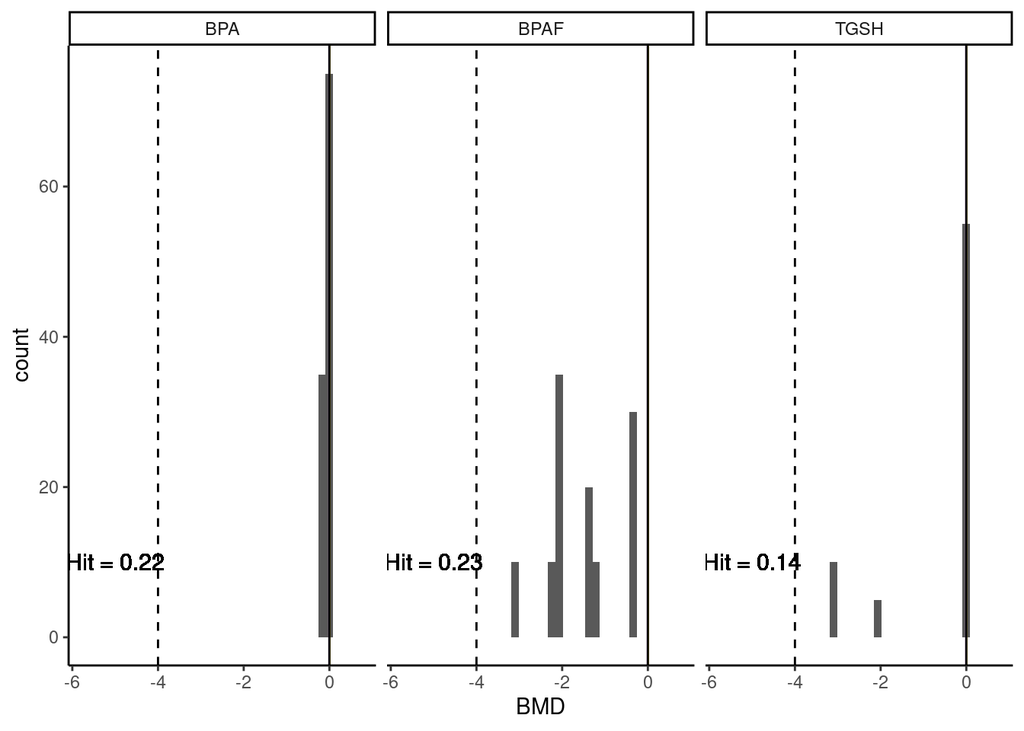

##### Distribution of BMDs from Rcurvep - Spearman c.c.

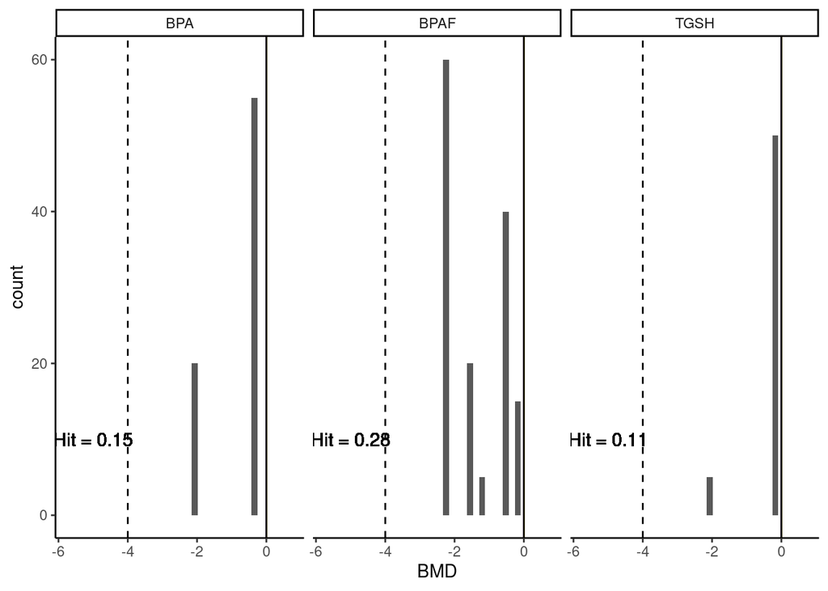

Table 9. Summary of all the benchmark doses (BMDs) of every chemical

| Chemical | endpoint | Low Dose | High Dose | BMD - low confidence interval (0.05) | BMD | BMD - high confidence interval (0.95) | Hit Confidence |
| --- | --- | --- | --- | --- | --- | --- | --- |
| BPA | rcurvep_pearson | 0.0001000 | 1.0000000 | 1.000 | 1.000 | 1.000 | 0.22 |
| BPA | rcurvep_spearman | 0.0001000 | 1.0000000 | 1.000 | 1.000 | 1.000 | 0.15 |
| BPA | fitted_pearson | 0.0001000 | 1.0000000 | 1.000 | NA | 1.000 | 0.00 |
| BPA | fitted_spearman | 0.0001000 | 1.0000000 | 1.000 | 1.000 | 1.000 | 0.00 |
| BPAF | rcurvep_pearson | 0.0001000 | 1.0000000 | 1.000 | 1.000 | 1.000 | 0.23 |
| BPAF | rcurvep_spearman | 0.0001000 | 1.0000000 | 1.000 | 1.000 | 1.000 | 0.28 |
| BPAF | fitted_pearson | 0.0001000 | 1.0000000 | 1.000 | NA | 1.000 | 0.00 |
| BPAF | fitted_spearman | 0.0001000 | 1.0000000 | 1.000 | 1.000 | 1.000 | 0.00 |
| DES | rcurvep_pearson | 0.0000100 | 0.1000000 | 0.100 | 0.100 | 0.100 | 0.00 |
| DES | rcurvep_spearman | 0.0000100 | 0.1000000 | 0.100 | 0.100 | 0.100 | 0.00 |
| DES | fitted_pearson | 0.0000100 | 0.1000000 | 0.100 | NA | 0.100 | 0.00 |
| DES | fitted_spearman | 0.0000100 | 0.1000000 | 0.100 | 0.100 | 0.100 | 0.00 |
| EE2 | rcurvep_pearson | 0.0000001 | 0.0010000 | 0.001 | 0.001 | 0.001 | 0.00 |
| EE2 | rcurvep_spearman | 0.0000001 | 0.0010000 | 0.001 | 0.001 | 0.001 | 0.00 |
| EE2 | fitted_pearson | 0.0000001 | 0.0010000 | 0.001 | NA | 0.001 | 0.00 |
| EE2 | fitted_spearman | 0.0000001 | 0.0010000 | 0.001 | 0.001 | 0.001 | 0.00 |
| TGSH | rcurvep_pearson | 0.0001000 | 1.0000000 | 1.000 | 1.000 | 1.000 | 0.14 |
| TGSH | rcurvep_spearman | 0.0001000 | 1.0000000 | 1.000 | 1.000 | 1.000 | 0.11 |
| TGSH | fitted_pearson | 0.0001000 | 1.0000000 | 1.000 | NA | 1.000 | 0.00 |
| TGSH | fitted_spearman | 0.0001000 | 1.0000000 | 1.000 | 1.000 | 1.000 | 0.00 |